# Graph Theory

Autumn 2025

## Drawing pretty pictures and solving interesting problems

## Prussian Bridges

[figure not shown]

Map of Konigsberg

## Bridges

- Euler spotted that the route taken within the landmass doesn’t matter, only the bridges crossed.
- Smaller island connected with \(2\) bridges to each side of the river.
- Larger island connected to each side of the river by \(1\) bridge.
- Islands connected by one bridge.
- Is it possible to walk around the city, crossing every bridge *exactly once*?

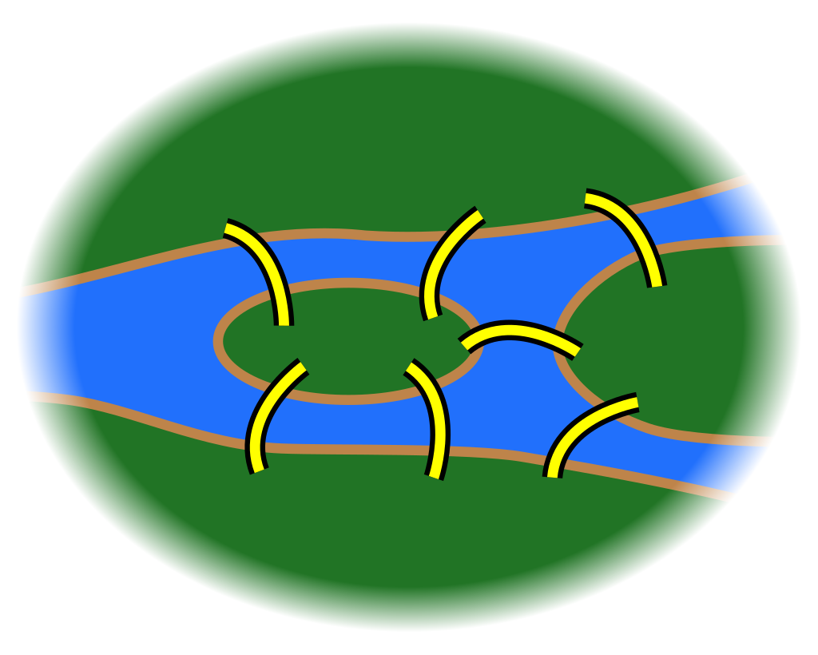

Simplified map, showing only the bridges and land-masses

[interactive chart not shown]

Can you solve the 7 bridges problem?

## Graphs

- Formally: a set of *objects* which are *related* in some way.
- Here *land masses* are related by *bridges*.

[interactive chart not shown]

## Nodes

- Nodes (aka vertices) are the objects,
- Here, nodes are Discworld novels.

[interactive chart not shown]

## Edges

- Edges (aka arcs, connections, arrows) define *relationsships* between nodes.
- “Wyrd Sisters” and “Equal rites” are connected by edges, being part of the Witches series,
- However, “Thief of Time” and “Night Watch” are not (although, some might argue they should be).

[interactive chart not shown]

## Neighbours

- Nodes that can be reached by traversing one edge.
- I.e., directly connected to a given node.

[interactive chart not shown]

## Degrees

- Number of neighbours of a given node
- I.e., number of nodes reachable by one edge traversal.

[interactive chart not shown]

## Connectedness

- So far we have looked at node-level properties, connectedness applies to the graph as a whole.
- Nodes that you can reach by traversing one or more edges.
- I.e., all nodes linked by edges to given node.
- Here we have three sets of nodes which are connected (connected components).

[interactive chart not shown]

## Paths

- Sequence of nodes, the next node in the sequence is connected to the current node by an edge.
- Defines a journey from one node to another by means of traversing edges.
- There is a path from “Wyrd Sisters” to “Jingo”.
- Actually, there are multiple paths; which is the shortest?

[interactive chart not shown]

[output not shown]

## Back to Konigsberg

- Smaller island connected with \(2\) bridges to each side of the river.
- Larger island connected to each side of the river by \(1\) bridge.
- Islands connected by \(1\) bridge.

[interactive chart not shown]

Is there a path that crosses each bridge *exactly once*?

[interactive chart not shown]

## Special types of graph

## Weighted Graphs

- A graph with values assigned to edges
- These can represent anything from *distance* to *cost* to *game scoring*.
- We often want to *maximise* or *minimise* the sum of edges in a path
- What is the shortest path from \(A\) to \(D\)?
  - Direct: \(6.8\),
  - Through \(C\): \(2.5 + 3.2 = 5.7\)
  - Through \(B\): \(! + 2.7 = 3.7\)

[interactive chart not shown]

## Acyclic Graphs

- Graphs containing no cycles

[interactive chart not shown]

## Directed Graphs

- So far we have seen graphs where edges- can be traversed in *both* directions
- Directed graphs indicate the direction of an edge.
- Notice that \(C\) now has no outward arrows.

[interactive chart not shown]

## Trees

- In computer science, trees grow downwards, with the *root* at the top.
- Special type of *directed acyclic graph*:
  - one node, called the *root* has no incoming edges,
  - all other nodes have exactly one incoming edge, called the *parent*
  - nodes with no outgoing edges are called *leaves*.

[interactive chart not shown]

## Applications

## Decision-making

Map out possible *events*, *actions* and *outcomes*.

[interactive chart not shown]

## State diagrams

Aids in designing and understanding complex systems

[interactive chart not shown]

## Graph traversal / search

- Process of finding a given node, or visiting every node in a graph.
- Different search algorithms visit nodes in different orders.

## DFS

- Start with a given node.
- Travel as far along a *path* as possible,
- Backtrack until there is an edge to an *unvisited* node.
- Repeat until all nodes are visited.

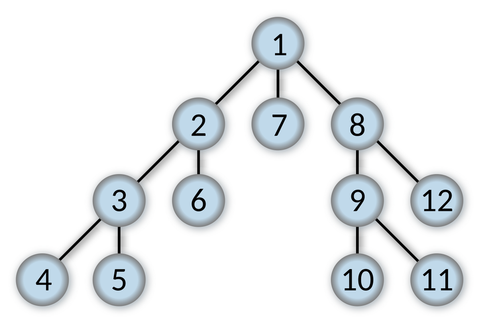

Visiting \(A\)

[interactive chart not shown]

Visiting \(B1\)

[interactive chart not shown]

Visiting \(C1\)

[interactive chart not shown]

Visiting \(D1\)

[interactive chart not shown]

\(D1\) is a *leaf*.

Visiting \(D2\)

[interactive chart not shown]

\(D2\) is a *leaf*.

Visiting \(C2\)

[interactive chart not shown]

Visiting \(D3\)

[interactive chart not shown]

\(D3\) is a *leaf*.

Visiting \(D5\)

[interactive chart not shown]

\(D5\) is a *leaf*.

Visiting \(C3\)

[interactive chart not shown]

Visiting \(B2\)

[interactive chart not shown]

Visiting \(C4\)

[interactive chart not shown]

Visiting \(D6\)

[interactive chart not shown]

\(D6\) is a *leaf*.

Visiting \(D7\)

[interactive chart not shown]

\(D7\) is a *leaf*.

## BFS

- Start with a given node.
- Visit all its neighbours.
- For each neighbour, repeat the process – i.e., visit all its neighbours (two steps from the start node).
- Repeat until all nodes ale visited.

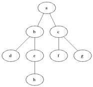

Visiting \(A\)

[interactive chart not shown]

Visiting \(B1\)

[interactive chart not shown]

Visiting \(B2\)

[interactive chart not shown]

Visiting \(C4\)

[interactive chart not shown]

Visiting \(C2\)

[interactive chart not shown]

Visiting \(C1\)

[interactive chart not shown]

Visiting \(C3\)

[interactive chart not shown]

Visiting \(D5\)

[interactive chart not shown]

\(D5\) is a *leaf*.

Visiting \(D7\)

[interactive chart not shown]

\(D7\) is a *leaf*.

Visiting \(D1\)

[interactive chart not shown]

\(D1\) is a *leaf*.

Visiting \(D2\)

[interactive chart not shown]

\(D2\) is a *leaf*.

Visiting \(D3\)

[interactive chart not shown]

\(D3\) is a *leaf*.

Visiting \(D6\)

[interactive chart not shown]

\(D6\) is a *leaf*.

## Random Search

- Simply visit nodes in *any order*.

## Graph Representations

## Adjacency matrix

- A square table of numbers
- Position \((i,j)\) in the table represents the connection from node \(i\) to node \(j\).
- If there is *no edge* between \(i\) and \(j\), then \((i,j) = 0\).
- If there is an edge, then \((i,j) = 1\), or equal to the weight of that edge.
- Requires \(\mathcal{O}(n^2)\) storage space (\(n\) is the number of nodes)

[interactive chart not shown]

| - | A | L | K | B |
| --- | --- | --- | --- | --- |
| A | 0 | 1 | 2 | 0 |
| L | 1 | 0 | 1 | 1 |
| K | 2 | 1 | 0 | 2 |
| B | 0 | 1 | 2 | 0 |

## Adjacency (or edge) set

- A list of pairs \((i,j)\).
- If \((i,j)\) is in the list, then there is an edge between \(i\) and \(j\).
- Simple representation, less easy to work with for some problems.

[interactive chart not shown]

- `(A,L)`,
- `(A,K)‘,’(A,K)’,
- `(L,K)`,
- `(L,B)`,
- ’(K,B)`,`(K,B)`

## Adjacency list

- For each node \(i\) with edges leaving it,
  - Create a list \((j_1,\ldots,j_k)\) of neighbours of node \(i\).
  - Simple to code, easy to work with.
- In some object-orientated representations, the neighbours might be *node objects*, but can alse just be node names.

[interactive chart not shown]

## Path finding and Route Planning

## Dijkstra

- Given a weighted graph, find the shortest path from a start node to every other node.

## A star

- Find the shortest path from a given start node to a destination.

## Travelling Salesperson

- Find the shortest path which visits every node.